# Authors

Nick Browen

February 12, 2019

```r
library(tidyverse)
library(scales)
library(tidytext)
library(lubridate)
library(stringr)
library(purrr)
library(curl)
library(topicmodels)
library(lexicon)
library(wordcloud)
library(reshape2)
```

```r
reorder_within <- function(x, by, within, fun = mean, sep = "___", ...) {
  new_x <- paste(x, within, sep = sep)
  stats::reorder(new_x, by, FUN = fun)
}

scale_x_reordered <- function(..., sep = "___") {
  reg <- paste0(sep, ".+$")
  ggplot2::scale_x_discrete(labels = function(x) gsub(reg, "", x), ...)
}
```

#### For Desktop

```r
tweets <- read.csv("tweets_te.csv")
tweets <- as_tibble(tweets)
tweets <- tweets %>% mutate(external_author_id = as.character(external_author_id),
                            author = as.character(author),
                            word = as.character(word),
                            token = as.character(token),
                            emoji = as.character(emoji),
                            region = as.character(region),
                            language = as.character(language),
                            account_type = as.character(account_type),
                            account_category = as.character(account_category),
                            publish_date = ymd_hms(publish_date),
                            harvested_date = ymd_hms(harvested_date),
                            emoji_bin = ifelse(is.na(emoji),"Word", "Emoji"))
```

##### don’t run everytime

```
tweets_te_subset <- sample_n(tweets, dim(tweets)[1]*0.05)
write.csv(tweets_te_subset, "tweets_te_subset.csv")
```

```r
tweets_subset <- read.csv("tweets_te_subset.csv")
tweets_subset <-as_tibble(tweets_subset)
tweets_subset <- tweets_subset %>% mutate(external_author_id = as.character(external_author_id),
                             author = as.character(author),
                             word = as.character(word),
                             token = as.character(token),
                             emoji = as.character(emoji),
                             region = as.character(region),
                             language = as.character(language),
                             account_type = as.character(account_type),
                             account_category = as.character(account_category),
                             publish_date = ymd_hms(publish_date),
                             harvested_date = ymd_hms(harvested_date),
                             emoji_bin = ifelse(is.na(emoji),"Word", "Emoji"))
```

#### For Laptop

```
tweets <- read.csv("tweets_te_subset.csv")
tweets <- as_tibble(tweets)
tweets <- tweets %>% mutate(external_author_id = as.character(external_author_id),
                             author = as.character(author),
                             word = as.character(word),
                             token = as.character(token),
                             emoji = as.character(emoji),
                             region = as.character(region),
                             language = as.character(language),
                             account_type = as.character(account_type),
                             account_category = as.character(account_category),
                             publish_date = ymd_hms(publish_date),
                             harvested_date = ymd_hms(harvested_date),
                             emoji_bin = ifelse(is.na(emoji),"Word", "Emoji"))
```

## Account Classification: Trump/Clinton Dominant

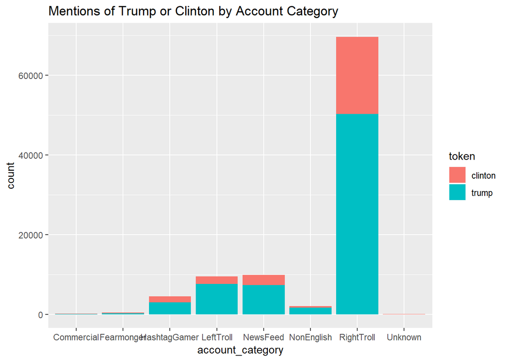

```r
tweets  %>%
    mutate(token = case_when(token == "donald"|token == "trump" ~ "trump",
                           token == "hillary"|token == "hilary"|token == "clinton" ~ "clinton")) %>%
    filter(token %in% c("trump", "clinton")) %>%
    ggplot(aes(account_category, fill = token)) + geom_bar() +
      labs(title = "Mentions of Trump or Clinton by Account Category")
```

Already, we can see that Trump is tweeted about much more the Clinton.

```r
proportion_tc <- tweets %>% filter(emoji_bin == "Word") %>%
  group_by(author) %>%
  count(token, sort = F) %>%
  mutate(total = sum(n), proportion = n/total) %>%
  filter(str_detect(token, "hilary|hillary|clinton|trump")) %>%
  mutate(token = case_when(str_detect(token, "trump") ~ "trump",
                           str_detect(token, "hilary|hillary|clinton") ~ "clinton")) %>%
  select(author,token, proportion) %>%
  group_by(author)%>%
  summarise(proportion = max(proportion))

proportion_authors <- tweets %>% filter(emoji_bin == "Word") %>%
  group_by(author) %>%
  count(token, sort = F) %>%
  mutate(total = sum(n), proportion = n/total) %>%
  filter(str_detect(token, "hilary|hillary|clinton|trump")) %>%
  mutate(token = case_when(str_detect(token, "trump") ~ "trump",
                           str_detect(token, "hilary|hillary|clinton") ~ "clinton")) %>%
  select(author,token, proportion)

author_dom <- proportion_tc %>%
  left_join(proportion_authors) %>%
  mutate(dominant = token, dominant_prop = proportion) %>%
  select(author, dominant, dominant_prop) %>%
  mutate(dominant = case_when(!author %in% .$author[duplicated(.$author)] ~ .$dominant, (author %in% .$author[duplicated(.$author)]) ~ "tie")) %>%
  distinct()
tweets <- tweets %>% left_join(author_dom)
```

Method: To assign an author (account) a classification of Trump or Clinton, I looked at the proportion of words that the account tweeted was Trump and proportion of words that were Clinton. (I considered “Donald”, “Trump” to be Trump and “Hillary”, “Hilary”, “Clinton” to be Clinton). If that account has a whole had a higher proportion of using the word “trump”, then it was classified as a Trump dominant category. Many accounts never tweeted about clinton or trump, so they are classified as NA. (Note: another method to do this would have been to do this tweet by tweet. So look if in each tweet “trump” was used more times than “clinton” and then classify that tweet as a trump or clinton tweet. Then see if that account has more trump or clinton tweets and classify that way,)

```r
tweets %>%
  distinct(author, .keep_all = T) %>%
  group_by(account_category) %>%
  summarise(no_tc = sum(is.na(dominant)), n = n(), proportion_notc = no_tc/n) %>%
  arrange(desc(proportion_notc))
```

```
## # A tibble: 8 x 4
##   account_category no_tc     n proportion_notc
##   <chr>            <int> <int>           <dbl>
## 1 Unknown             73    86           0.849
## 2 NonEnglish         492   627           0.785
## 3 Fearmonger          44    69           0.638
## 4 LeftTroll          111   180           0.617
## 5 HashtagGamer        46    94           0.489
## 6 RightTroll         182   471           0.386
## 7 NewsFeed             6    22           0.273
## 8 Commercial           0     5           0
```

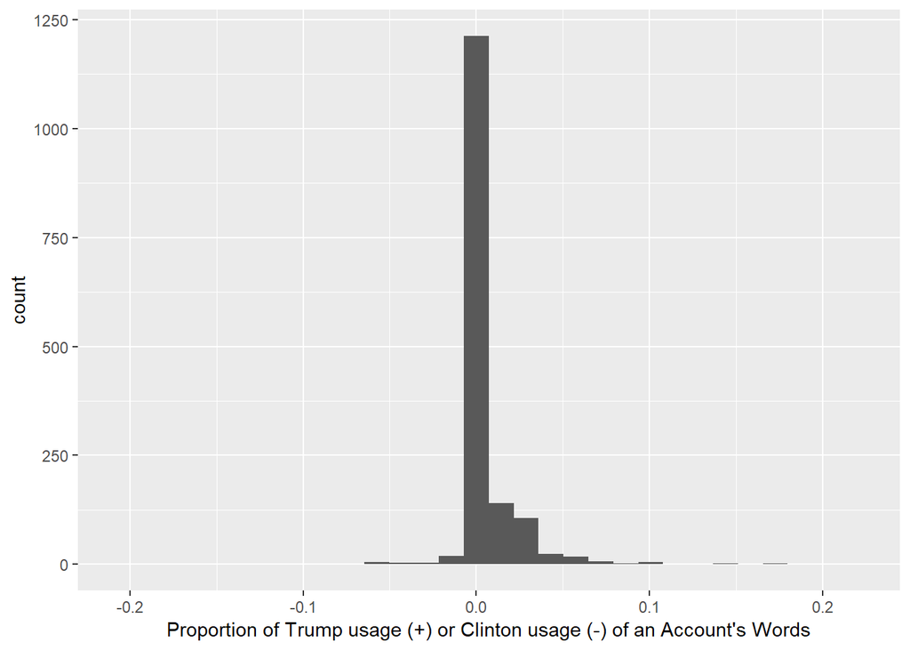

```r
tweets %>% distinct(author, .keep_all = T) %>%
    mutate(domprop_scale = case_when(
        dominant == "clinton" ~ dominant_prop*-1,
        dominant == "tie" ~ 0,
        is.na(dominant) ~ 0,
        dominant == "trump" ~ dominant_prop)) %>%
    ggplot() + geom_histogram(aes(domprop_scale)) +
    labs(x = "Proportion of Trump usage (+) or Clinton usage (-) of an Account's Words")
```

Most accounts have low proportions of how much they mention Trump or Clinton. However, we can see many more accounts mention Trump at a higher rate.

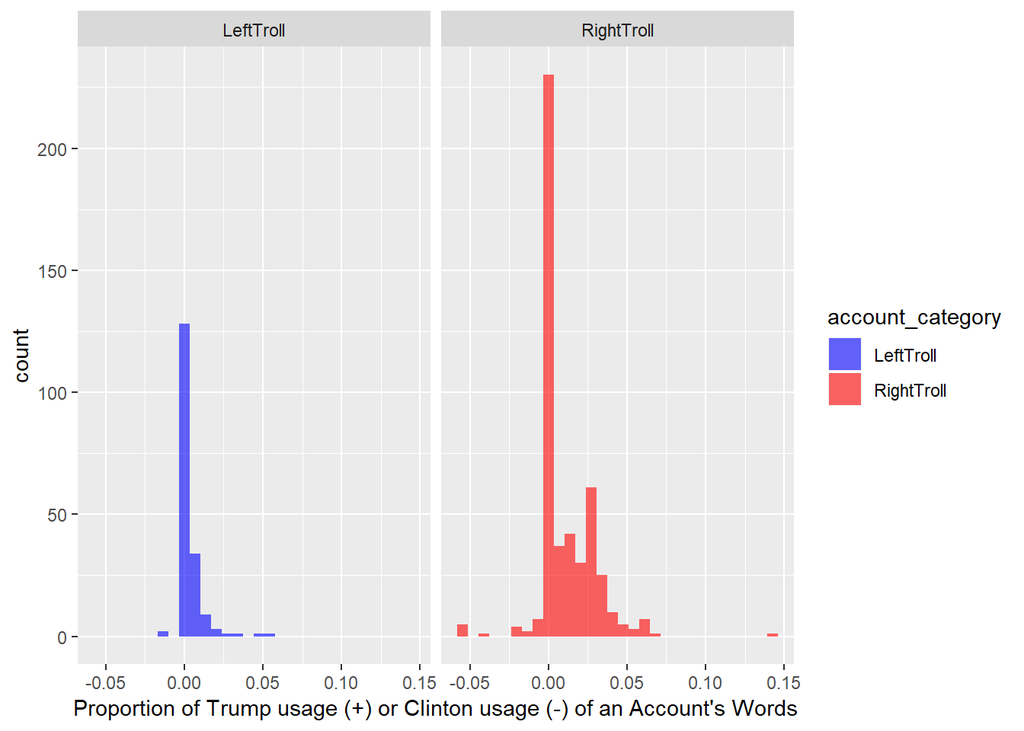

```r
tweets %>% distinct(author, .keep_all = T) %>% filter(account_category %in% c("LeftTroll", "RightTroll")) %>%
    mutate(domprop_scale = case_when(
        dominant == "clinton" ~ dominant_prop*-1,
        dominant == "tie" ~ 0,
        is.na(dominant) ~ 0,
        dominant == "trump" ~ dominant_prop)) %>%
    ggplot() + geom_histogram(aes(domprop_scale, fill = account_category), alpha = .6)  +
      facet_wrap(~account_category) +
      scale_fill_manual(values=c("blue", "red")) +
      labs(x = "Proportion of Trump usage (+) or Clinton usage (-) of an Account's Words")
```

The accounts classified as LeftTroll category have a higher proportion of accounts around 0 of Trump or Clinton dominant usage. The RightTroll accounts also peak at 0, but have many more accounts with a higher proportion of mentioning Trump dominantly.

```r
num_authors <- tweets %>% distinct(author, .keep_all = T) %>% group_by(account_category) %>% summarise(n_authors = n())

tweets %>% distinct(author, .keep_all = T) %>%
  group_by(dominant, account_category) %>%
  summarise(n=n()) %>%
  arrange(dominant, desc(n)) %>%
  left_join(num_authors, by = "account_category") %>%
  mutate(prop_accountcat = n/n_authors) %>%
  top_n(3) %>% arrange(dominant,desc(prop_accountcat))
```

```
## # A tibble: 12 x 5
## # Groups:   dominant [4]
##    dominant account_category     n n_authors prop_accountcat
##    <chr>    <chr>            <int>     <int>           <dbl>
##  1 clinton  Commercial           2         5          0.4
##  2 clinton  Unknown              8        86          0.0930
##  3 clinton  Fearmonger           6        69          0.0870
##  4 tie      Commercial           2         5          0.4
##  5 tie      RightTroll          41       471          0.0870
##  6 tie      Fearmonger           4        69          0.0580
##  7 trump    NewsFeed            15        22          0.682
##  8 trump    RightTroll         226       471          0.480
##  9 trump    HashtagGamer        44        94          0.468
## 10 <NA>     Unknown             73        86          0.849
## 11 <NA>     NonEnglish         492       627          0.785
## 12 <NA>     Fearmonger          44        69          0.638
```

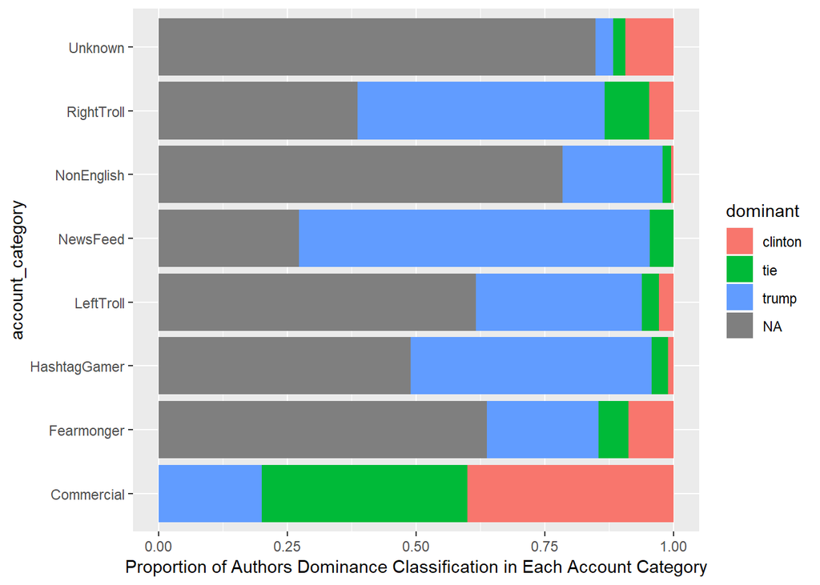

```r
tweets %>% distinct(author, .keep_all = T) %>%
    group_by(dominant, account_category) %>%
    summarise(n=n()) %>%
    arrange(dominant, desc(n)) %>%
    left_join(num_authors, by = "account_category") %>%
    mutate(prop_accountcat = n/n_authors) %>%
    arrange(dominant,desc(prop_accountcat)) %>%
    ggplot(aes(account_category, prop_accountcat, fill = dominant)) + geom_col() +
      coord_flip() +
      labs(y = "Proportion of Authors Dominance Classification in Each Account Category")
```

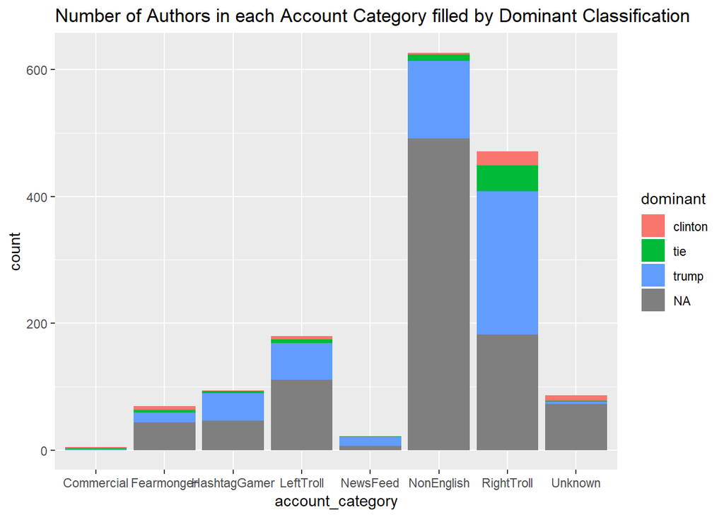

```r
tweets  %>% distinct(author, .keep_all = T) %>% ggplot(aes(account_category, fill = dominant)) +geom_bar() + labs(title = "Number of Authors in each Account Category filled by Dominant Classification")
```

The RightTroll category by raw number of accounts has the most authors that tweet more about Trump than Clinton, but, also in just numbers of accounts, RightTroll has the most authors that tweet about Clinton more than Trump.

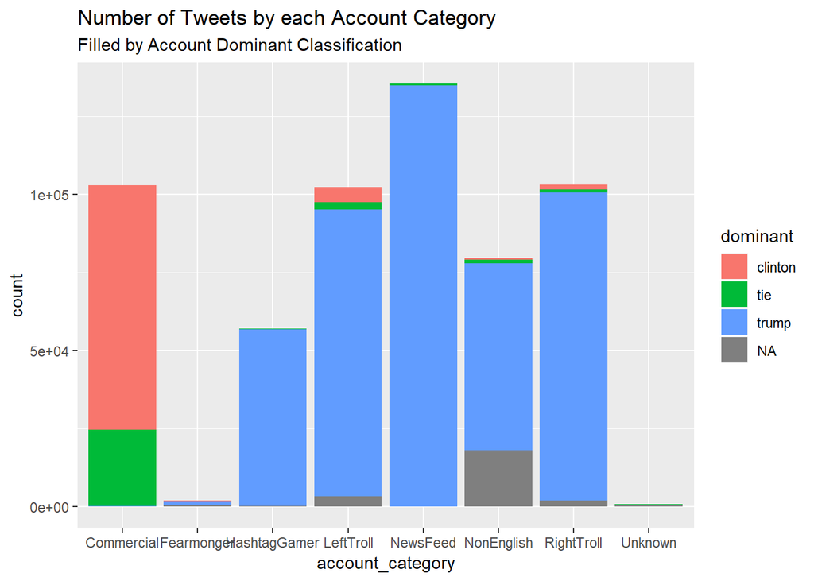

```r
tweets  %>% distinct(tweet_id, .keep_all = T) %>% ggplot(aes(account_category, fill = dominant)) +geom_bar() + labs(title = "Number of Tweets by each Account Category", subtitle = "Filled by Account Dominant Classification")
```

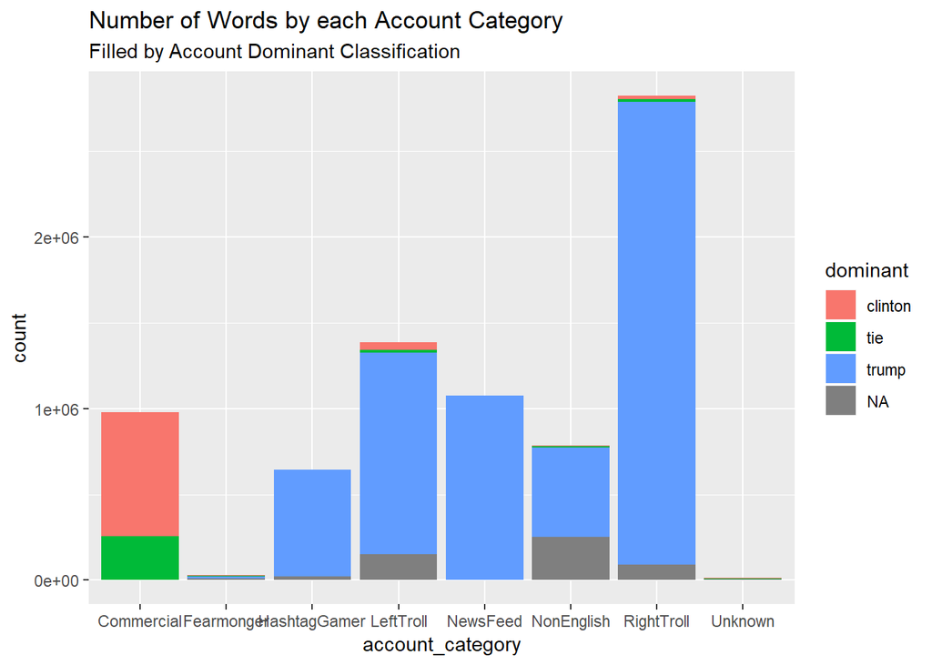

```r
tweets%>% ggplot(aes(account_category, fill = dominant)) +geom_bar() + labs(title = "Number of Words by each Account Category", subtitle = "Filled by Account Dominant Classification")
```

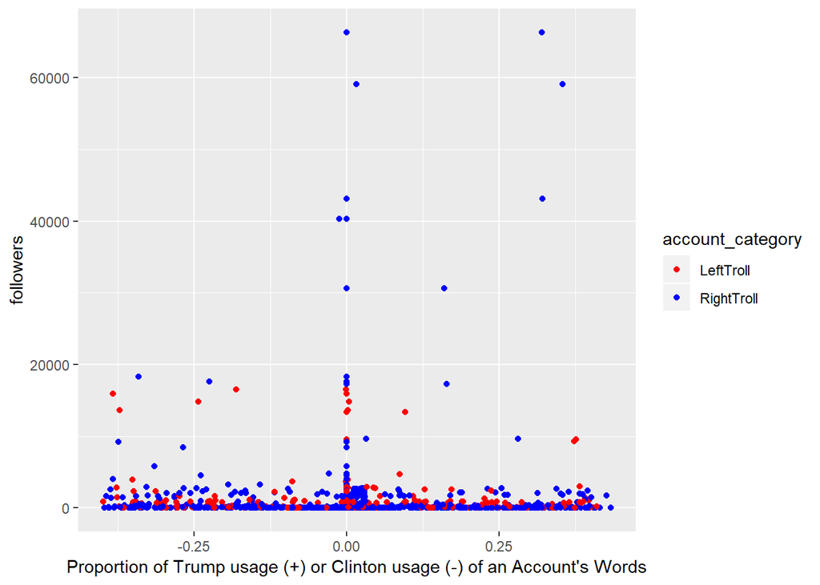

```r
tweets %>% distinct(author, .keep_all = T) %>% filter(account_category %in% c("LeftTroll", "RightTroll")) %>%
    mutate(domprop_scale = case_when(
        dominant == "clinton" ~ dominant_prop*-1,
        dominant == "tie" ~ 0,
        is.na(dominant) ~ 0,
        dominant == "trump" ~ dominant_prop)) %>%
    ggplot(aes(y = followers, x = domprop_scale, color = account_category)) +
  geom_point() + geom_jitter(width = .4, height = .4) +
  scale_color_manual(values = c("red", "blue")) +
  labs(x = "Proportion of Trump usage (+) or Clinton usage (-) of an Account's Words")
```

No discernible pattern. RightTrolls have more larger outliers for amount of followers.

## Update Activity (each unit a tweet)

Updates - “The number of ‘update actions’ on the account that authored the tweet, including tweets, retweets and likes

```r
tweet_updates <- tweets %>%  distinct(tweet_id, .keep_all = T) %>%
  arrange(author, publish_date)  %>%
  group_by(author) %>%
  arrange(author, publish_date) %>%
  mutate(lag_updates = lag(updates, default = 0))  %>%
  mutate(new_updates = case_when(lag_updates == 0 ~ as.numeric(0),
                                 lag_updates != 0 ~ as.numeric(updates - lag_updates))) %>%
  ungroup()
```

```r
tweet_updates %>% select(updates, lag_updates) %>% cor()
```

```
##             updates lag_updates
## updates     1.00000     0.99991
## lag_updates 0.99991     1.00000
```

The Updates variable included the tweets by the account, so every time that account tweeted their updates increased by one. This resulted in just large updates overtime. And accounts that tweeted alot would have very high update values. I am more curious in the retweets and likes that the tweets and account get. To solve this, on the tweet level, I lagged the update variable and subtracted it from the original. (Note: there are some weird cases where the update variable goes back down for some reason and my new update variable is negative. Seems to happen when updates occur in the same exact time, but here are also cases where that isn’t true and the updates value goes down. So I’m not sure.)

```r
tweet_updates %>% select(updates, new_updates) %>% summary()
```

```
##     updates        new_updates
##  Min.   :     1   Min.   :-4774.000
##  1st Qu.:  2077   1st Qu.:    1.000
##  Median :  6770   Median :    1.000
##  Mean   : 13829   Mean   :    3.917
##  3rd Qu.: 18247   3rd Qu.:    3.000
##  Max.   :166113   Max.   :10419.000
```

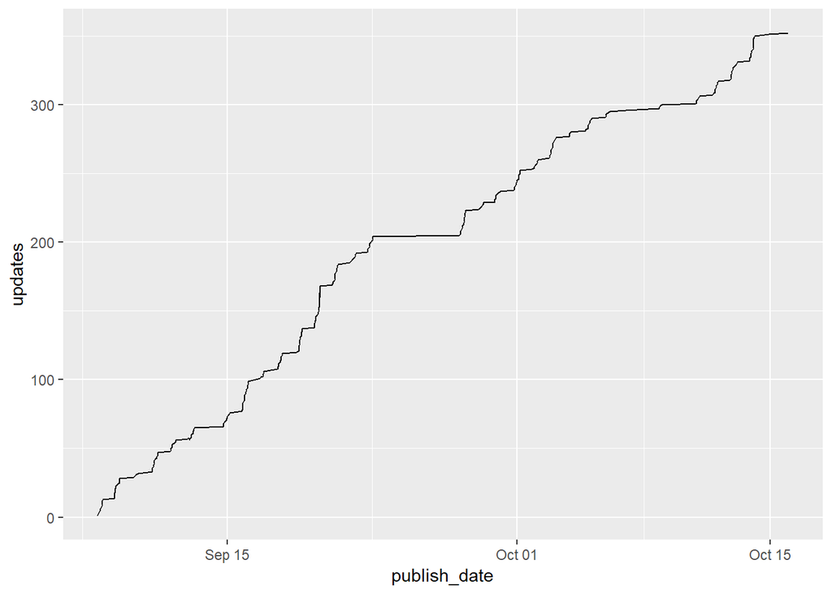

```r
tweet_updates %>% filter(author == "10_GOP") %>% ggplot()+geom_line(aes(y=updates, x=publish_date))
```

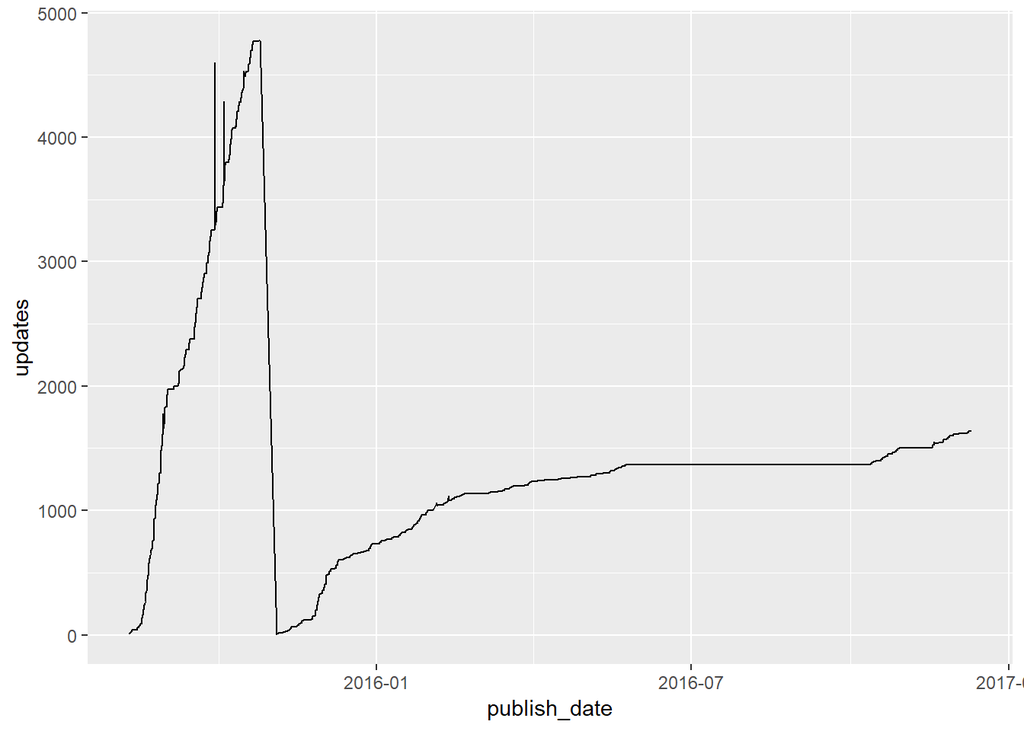

```r
tweet_updates %>% filter(author == "4MYSQUAD") %>% ggplot()+geom_line(aes(y=updates, x=publish_date))
```

You can see 10_GOP is always increasing. But then 4MYSQUAD resets from 4775 on 10-25-2015 to 1 on 11-04-2015

```r
tweet_updates %>% select(new_updates, account_category, tweet_id) %>%
    group_by(account_category) %>%
    summarise(mean = mean(new_updates), sd = sd(new_updates)) %>%
    arrange(desc(mean))
```

```
## # A tibble: 8 x 3
##   account_category  mean    sd
##   <chr>            <dbl> <dbl>
## 1 NonEnglish       9.56   64.1
## 2 RightTroll       5.57   41.8
## 3 HashtagGamer     4.61   63.2
## 4 LeftTroll        4.25   30.8
## 5 Unknown          3.07   19.1
## 6 Fearmonger       2.25   10.9
## 7 Commercial       1.18   15.5
## 8 NewsFeed         0.911  21.1
```

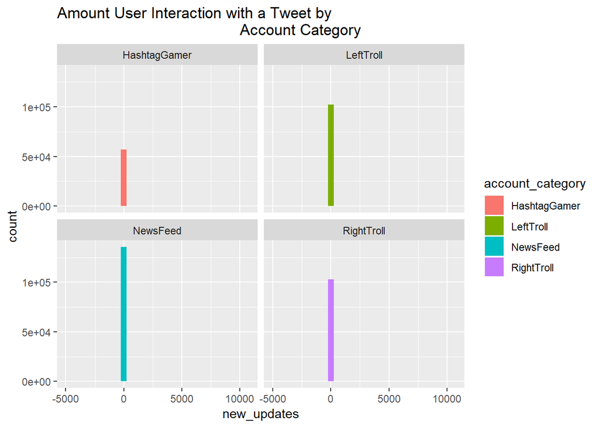

```r
tweet_updates %>%
  filter(account_category %in% c("RightTroll", "LeftTroll", "NewsFeed", "HashtagGamer")) %>%    ggplot(aes(new_updates, fill = account_category)) + geom_histogram() +
    facet_wrap(~account_category) + labs(title = "Amount User Interaction with a Tweet by
                                         Account Category")
```

These histograms look so bad because there are a few value of new_updates that are (very) negative, such as -4774. But also, there are oddly high ones like 10419.

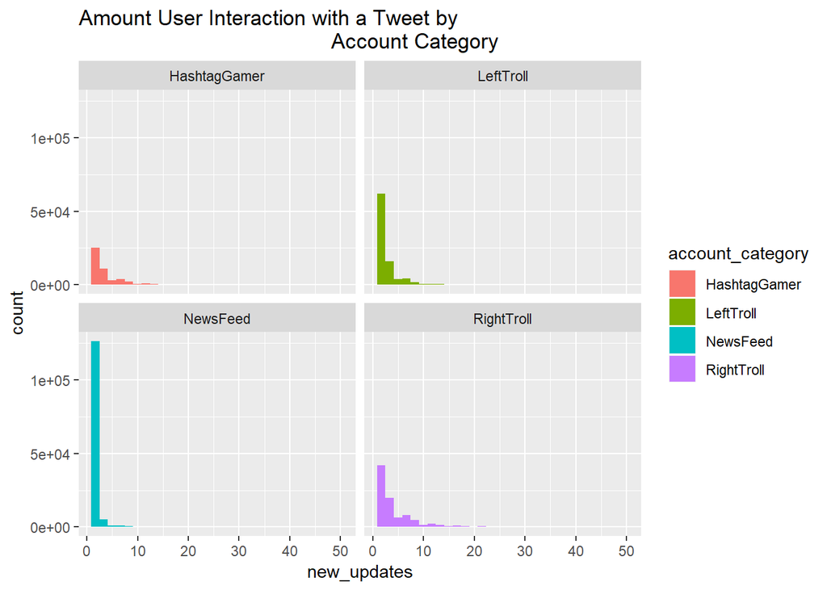

```r
tweet_updates %>% filter(new_updates > 0, new_updates < 50) %>%
  filter(account_category %in% c("RightTroll", "LeftTroll", "NewsFeed", "HashtagGamer")) %>%    ggplot(aes(new_updates, fill = account_category)) + geom_histogram() +
    facet_wrap(~account_category) + labs(title = "Amount User Interaction with a Tweet by
                                         Account Category")
```

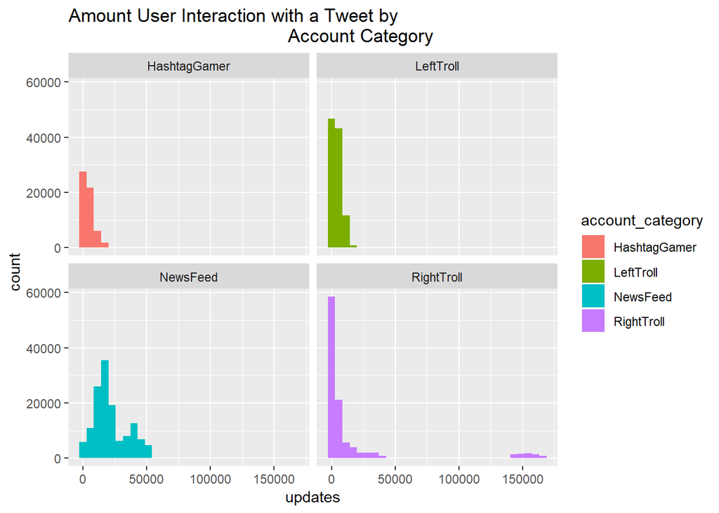

```r
tweet_updates %>% #filter(new_updates > 0, new_updates < 50) %>%
  filter(account_category %in% c("RightTroll", "LeftTroll", "NewsFeed", "HashtagGamer")) %>%    ggplot(aes(updates, fill = account_category)) + geom_histogram() +
    facet_wrap(~account_category) + labs(title = "Amount User Interaction with a Tweet by
                                         Account Category")
```

Looking at both the updates variable and new_updates variable, the shapes of the distribution of updates don’t change very much depending on which variable we use.

```r
tweet_updates %>%  filter(account_category %in% c("RightTroll", "LeftTroll", "NewsFeed", "HashtagGamer")) %>% group_by(account_category) %>% summarise(mean_updates = mean(updates), mean_newupdates = mean(new_updates)) %>% arrange(desc(mean_updates))
```

```
## # A tibble: 4 x 3
##   account_category mean_updates mean_newupdates
##   <chr>                   <dbl>           <dbl>
## 1 NewsFeed               21575.           0.911
## 2 RightTroll             15276.           5.57
## 3 HashtagGamer            4239.           4.61
## 4 LeftTroll               4081.           4.25
```

However, it does change the ordering of which categories have the highest average updates.

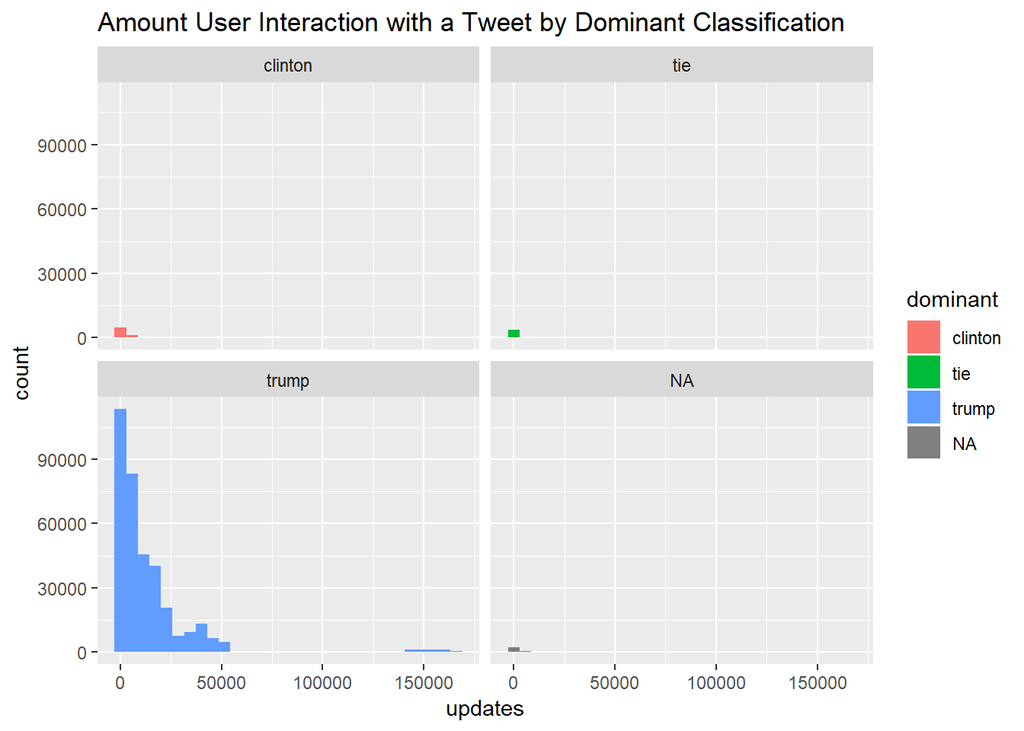

```r
tweet_updates%>% filter(new_updates > 0, new_updates < 50) %>%
  filter(account_category %in% c("RightTroll", "LeftTroll", "NewsFeed", "HashtagGamer")) %>%
  ggplot(aes(updates, fill =dominant)) + geom_histogram() + facet_wrap(~dominant) +
  labs(title = "Amount User Interaction with a Tweet by Dominant Classification")
```

[figure not shown]

```
tweets %>% distinct(tweet_id, .keep_all = T) %>% ggplot(aes(x= followers, y = updates)) + geom_point() + geom_smooth(method = "loess", se = F)
```

```
tweets  %>%
  filter(account_category %in% c("RightTroll", "LeftTroll", "NewsFeed", "HashtagGamer")) %>%
  distinct(tweet_id, .keep_all = T) %>%
  ggplot() + geom_point(aes(x = followers, y = updates, color = account_category)) +
  labs(title = "Updates vs. Followers for Tweets by Account Category")
```

```r
tweets %>%
  filter(account_category %in% c("RightTroll", "LeftTroll", "NewsFeed", "HashtagGamer")) %>%
  distinct(tweet_id, .keep_all = T) %>%
  ggplot(aes(updates, fill =dominant)) + geom_histogram() + facet_wrap(~dominant) +
  labs(title = "Amount User Interaction with a Tweet by Dominant Classification")
```

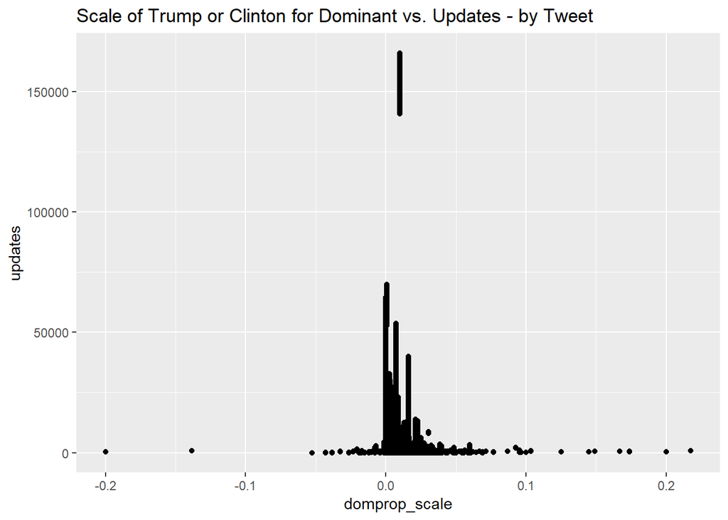

```r
tweets %>% distinct(tweet_id, .keep_all = T) %>%
  mutate(domprop_scale = case_when(
                            dominant == "clinton" ~ dominant_prop*-1,
                            dominant == "tie" ~ 0,
                            is.na(dominant) ~ 0,
                            dominant == "trump" ~ dominant_prop)) %>%
  ggplot() + geom_point(aes(y = updates, x = domprop_scale)) +
    labs(title = "Scale of Trump or Clinton for Dominant vs. Updates - by Tweet")
```

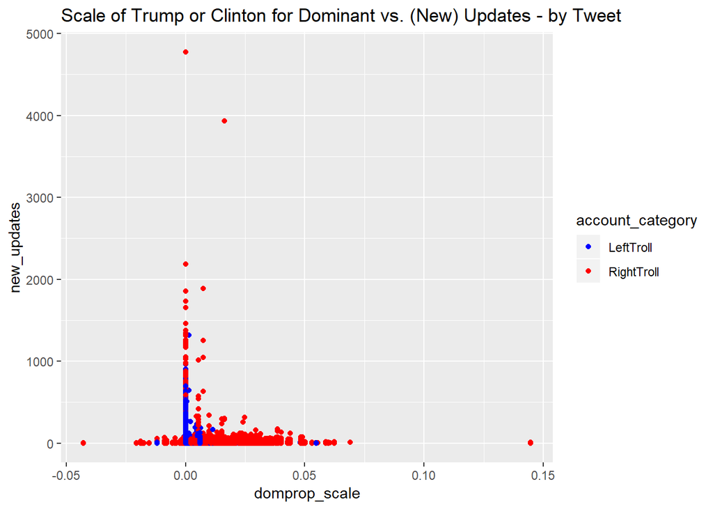

```r
tweet_updates %>% filter(new_updates >0, account_category %in% c("LeftTroll", "RightTroll")) %>%
    mutate(domprop_scale = case_when(
        dominant == "clinton" ~ dominant_prop*-1,
        dominant == "tie" ~ 0,
        is.na(dominant) ~ 0,
        dominant == "trump" ~ dominant_prop)) %>%
    ggplot() + geom_point(aes(y = new_updates, x = domprop_scale, color = account_category)) +
    labs(title = "Scale of Trump or Clinton for Dominant vs. (New) Updates - by Tweet") + scale_color_manual(values=c("blue", "red"))
```

```r
afinn <- get_sentiments("afinn")

tweets_sentiment <- tweets %>% inner_join(afinn) %>% mutate(afinn_score = score) %>% select(-score)
tweets_sentiment %>% group_by(dominant) %>%
  summarise(mean = mean(afinn_score)) %>%
  arrange(mean)
```

```
## # A tibble: 4 x 2
##   dominant    mean
##   <chr>      <dbl>
## 1 trump    -0.650
## 2 <NA>     -0.212
## 3 tie      -0.177
## 4 clinton  -0.0534
```

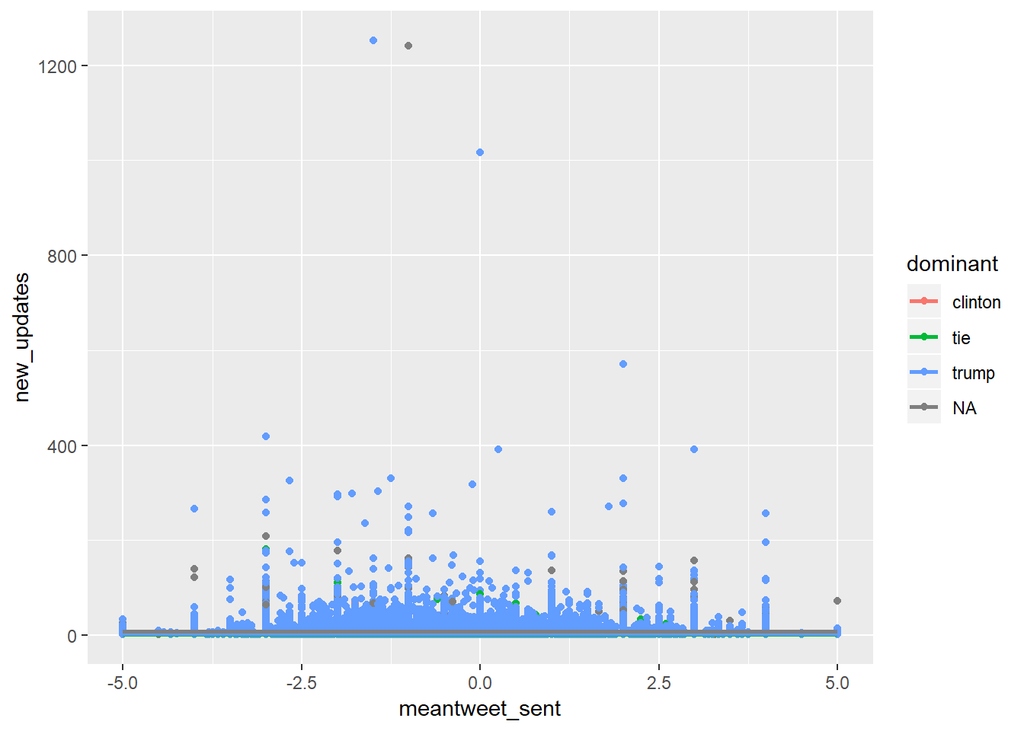

```r
tweets_sentiment %>% group_by(tweet_id) %>%
    summarise(meantweet_sent = mean(afinn_score), tweet_words = n()) %>%
    left_join(tweet_updates) %>%  distinct(tweet_id, .keep_all = T) %>% filter(new_updates >0) %>%
    ggplot(aes(y = new_updates, x = meantweet_sent, color = dominant)) + geom_point() +
    geom_smooth(method = "lm", se = F)
```

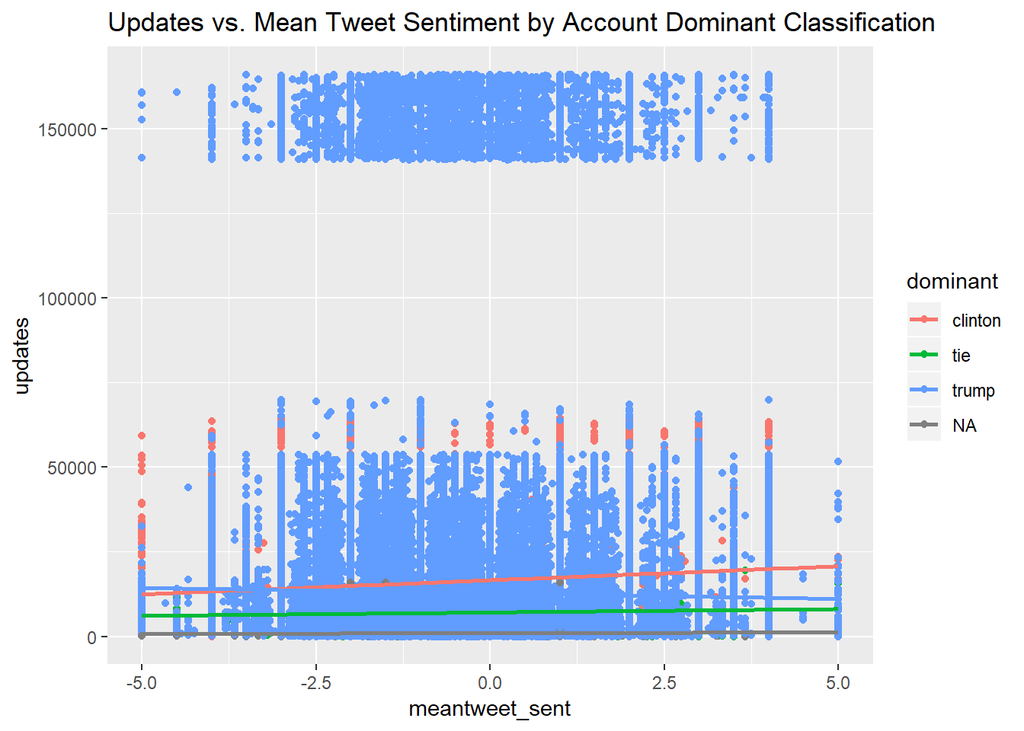

```r
tweets_sentiment %>%
  group_by(tweet_id) %>%
  summarise(meantweet_sent = mean(afinn_score), tweet_words = n()) %>%
  left_join(tweets_sentiment %>% distinct(tweet_id, .keep_all = T)) %>%
  ggplot(aes(y = updates, x = meantweet_sent, color = dominant)) + geom_point() +
    geom_smooth(method = "lm", se = F) +
    labs(title = "Updates vs. Mean Tweet Sentiment by Account Dominant Classification")
```